# Example Quarto slides

with some thoughts on how to set up things

2026-01-01

## Overview

- A few simple slides using the [`revealjs` (html) format](https://quarto.org/docs/presentations/revealjs/).
- For other formats (e.g. PowerPoint, or Beamer/pdf), see [here](https://quarto.org/docs/guide/).

## Figures and tables

The suggestion is to place figures/tables/RDS files etc. in the `media` folder.

You could also pull it from the `results` folder, but the advantage of copying them into `media` is that you have everything related to your presentation in one place, and if content in `results` continues to be changed/updated, you can ensure you have the version you used in your presentation by copying it into `media`.

## Example slide

This shows the summary table. It is pulled in from an RDS file and rendered in an R chunk with the `flextable` package, which is the default table package for this template (see `code-guidelines.md`). Other good options are `gt`, or `knitr::kable()` when a plain, minimal table is all you need.

Note that we could have loaded the data with `here()`, but if we ever want to copy this presentation to another folder outside the current project, you would have to adjust the path.

| Variable | Type | Missing | Mean | SD | Min | Median | Max | Categories |
| --- | --- | --- | --- | --- | --- | --- | --- | --- |
| Gender | factor | 0 |  |  |  |  |  | M: 4, F: 3, O: 2 |
| Height | numeric | 0 | 165.7 | 16.0 | 133 | 166 | 183 |  |
| Weight | numeric | 0 | 70.1 | 21.2 | 45 | 70 | 110 |  |

Table 1: Data summary table.

## Example slide

This shows a figure created by the analysis script. It is inserted using Quarto/Markdown syntax (not knitr code, but that would be possible too).

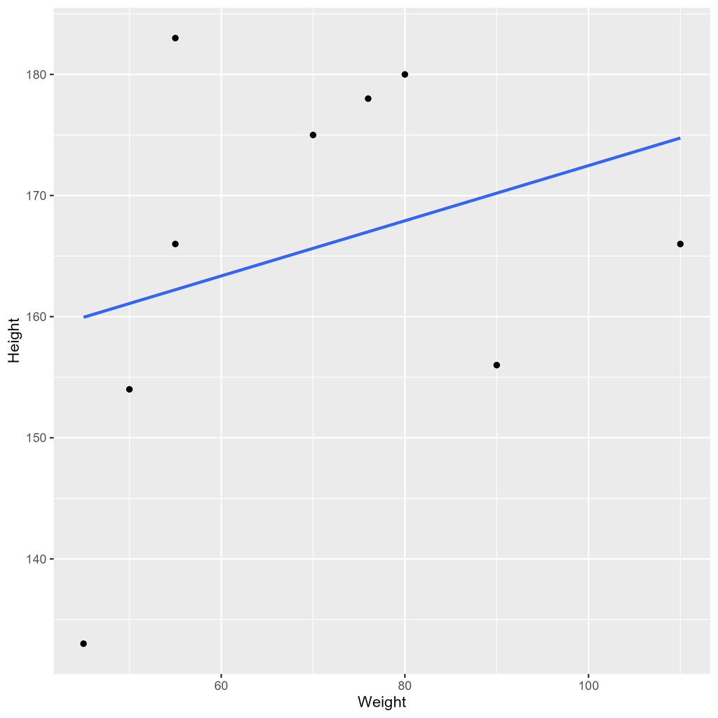

## Example slide

This shows the model fitting results as table.

| term | estimate | std.error | statistic | p.value |
| --- | --- | --- | --- | --- |
| (Intercept) | 149.2726967 | 23.3823360 | 6.3839942 | 0.001396202 |
| Weight | 0.2623972 | 0.3512436 | 0.7470519 | 0.488651747 |
| GenderM | -2.1244913 | 15.5488953 | -0.1366329 | 0.896652025 |
| GenderO | -4.7644739 | 19.0114155 | -0.2506112 | 0.812087104 |

Table 2: Linear model fit table.

## Example slide with reference

This paper (1) discusses types of analyses.

## Further Resources

- [Quarto Presentation Documentation](https://quarto.org/docs/presentations/)
- [Slidecraft 101](https://emilhvitfeldt.com/project/slidecraft-101/) is a nice blog post showing some more advanced things one can do with Quarto slides.

## References

1.

Leek JT, Peng RD. [Statistics. What is the question?](https://doi.org/10.1126/science.aaa6146) *Science (New York, N.Y.)*. 2015;347(6228):1314–1315.